# Project 2: Dataset Analysis (TMDB Movies)

> The primary objective of this analysis is to investigate the TMDB Movies dataset using the standard data analysis process that can be easily navigated using the below table of contents. The analysis will be conducted by adapting the use of libraries such as pandas, numpy and matplotlib developed by the Python object oriented programming language.
- Introduction
- Data Wrangling
- Exploratory Data Analysis
- Conclusions

## Introduction

### Questions

1. Is that data distributed noramlly across key variables?
2. Movies with the highest and lowest revenue and what year were the Movies made?
3. What are the Movies that contain the highest and the lowest budgets and what production companies made the film?
4. What are the top five Movies with the highest profit?
5. Plot Vote Average vs Profit to see if the most profitable movies matched the highest average votes?
6. Is there a strong correlation between Revenue and Profit, and between Budget and Profit?
7. What Genres feature most frequently within the data.
8. Do the number of Movies released increase by year and how do budget, reveunue and profit trend over time.

```python
import pandas as pd #importing pandas - data manipulation library
import numpy as np #importing numpy - provides numerical arrays and functions that manipulate the arrays effectively
import collections as cs

import matplotlib.pyplot as plt # importing matplotlib - data visualization library
import seaborn as sb #built on matplotlib for extra visualizations

#% matplotlib inline
#to ensure graphs render properly
```

## Data Wrangling

> In this section of the report, I will load in the TMDB Movies dataset, check for cleanliness within the dataset, and then trim and clean the dataset for analysis.

### General Properties

```python
#reading in TMDB Movies dataset
df = pd.read_csv("tmdb-movies.csv",sep=',')

df.info() #first look at the dataset in Jupyter notebook

df.head() #inspecting the first five rows of the datset
#df.tail() #inspecting final five rows of datset where we can see missing attributes are replaced with NaN
```

```
<class 'pandas.core.frame.DataFrame'>
RangeIndex: 10866 entries, 0 to 10865
Data columns (total 21 columns):
 #   Column                Non-Null Count  Dtype
---  ------                --------------  -----
 0   id                    10866 non-null  int64
 1   imdb_id               10856 non-null  object
 2   popularity            10866 non-null  float64
 3   budget                10866 non-null  int64
 4   revenue               10866 non-null  int64
 5   original_title        10866 non-null  object
 6   cast                  10790 non-null  object
 7   homepage              2936 non-null   object
 8   director              10822 non-null  object
 9   tagline               8042 non-null   object
 10  keywords              9373 non-null   object
 11  overview              10862 non-null  object
 12  runtime               10866 non-null  int64
 13  genres                10843 non-null  object
 14  production_companies  9836 non-null   object
 15  release_date          10866 non-null  object
 16  vote_count            10866 non-null  int64
 17  vote_average          10866 non-null  float64
 18  release_year          10866 non-null  int64
 19  budget_adj            10866 non-null  float64
 20  revenue_adj           10866 non-null  float64
dtypes: float64(4), int64(6), object(11)
memory usage: 1.7+ MB
```

|  | id | imdb_id | popularity | budget | revenue | original_title | cast | homepage | director | tagline | ... | overview | runtime | genres | production_companies | release_date | vote_count | vote_average | release_year | budget_adj | revenue_adj |
| --- | --- | --- | --- | --- | --- | --- | --- | --- | --- | --- | --- | --- | --- | --- | --- | --- | --- | --- | --- | --- | --- |
| 0 | 135397 | tt0369610 | 32.985763 | 150000000 | 1513528810 | Jurassic World | Chris Pratt\|Bryce Dallas Howard\|Irrfan Khan\|Vi... | http://www.jurassicworld.com/ | Colin Trevorrow | The park is open. | ... | Twenty-two years after the events of Jurassic ... | 124 | Action\|Adventure\|Science Fiction\|Thriller | Universal Studios\|Amblin Entertainment\|Legenda... | 6/9/15 | 5562 | 6.5 | 2015 | 1.379999e+08 | 1.392446e+09 |
| 1 | 76341 | tt1392190 | 28.419936 | 150000000 | 378436354 | Mad Max: Fury Road | Tom Hardy\|Charlize Theron\|Hugh Keays-Byrne\|Nic... | http://www.madmaxmovie.com/ | George Miller | What a Lovely Day. | ... | An apocalyptic story set in the furthest reach... | 120 | Action\|Adventure\|Science Fiction\|Thriller | Village Roadshow Pictures\|Kennedy Miller Produ... | 5/13/15 | 6185 | 7.1 | 2015 | 1.379999e+08 | 3.481613e+08 |
| 2 | 262500 | tt2908446 | 13.112507 | 110000000 | 295238201 | Insurgent | Shailene Woodley\|Theo James\|Kate Winslet\|Ansel... | http://www.thedivergentseries.movie/#insurgent | Robert Schwentke | One Choice Can Destroy You | ... | Beatrice Prior must confront her inner demons ... | 119 | Adventure\|Science Fiction\|Thriller | Summit Entertainment\|Mandeville Films\|Red Wago... | 3/18/15 | 2480 | 6.3 | 2015 | 1.012000e+08 | 2.716190e+08 |
| 3 | 140607 | tt2488496 | 11.173104 | 200000000 | 2068178225 | Star Wars: The Force Awakens | Harrison Ford\|Mark Hamill\|Carrie Fisher\|Adam D... | http://www.starwars.com/films/star-wars-episod... | J.J. Abrams | Every generation has a story. | ... | Thirty years after defeating the Galactic Empi... | 136 | Action\|Adventure\|Science Fiction\|Fantasy | Lucasfilm\|Truenorth Productions\|Bad Robot | 12/15/15 | 5292 | 7.5 | 2015 | 1.839999e+08 | 1.902723e+09 |
| 4 | 168259 | tt2820852 | 9.335014 | 190000000 | 1506249360 | Furious 7 | Vin Diesel\|Paul Walker\|Jason Statham\|Michelle ... | http://www.furious7.com/ | James Wan | Vengeance Hits Home | ... | Deckard Shaw seeks revenge against Dominic Tor... | 137 | Action\|Crime\|Thriller | Universal Pictures\|Original Film\|Media Rights ... | 4/1/15 | 2947 | 7.3 | 2015 | 1.747999e+08 | 1.385749e+09 |

5 rows × 21 columns

```python
df.isna().sum() # investigating the null values further and counting null values per column
#df.isna().sum().sum() #how many are there in total
```

```
id                         0
imdb_id                   10
popularity                 0
budget                     0
revenue                    0
original_title             0
cast                      76
homepage                7930
director                  44
tagline                 2824
keywords                1493
overview                   4
runtime                    0
genres                    23
production_companies    1030
release_date               0
vote_count                 0
vote_average               0
release_year               0
budget_adj                 0
revenue_adj                0
dtype: int64
```

```python
df.isna().sum()/(len(df))*100 #what percentage of each column contains missing values
```

```
id                       0.000000
imdb_id                  0.092030
popularity               0.000000
budget                   0.000000
revenue                  0.000000
original_title           0.000000
cast                     0.699429
homepage                72.979937
director                 0.404933
tagline                 25.989324
keywords                13.740107
overview                 0.036812
runtime                  0.000000
genres                   0.211669
production_companies     9.479109
release_date             0.000000
vote_count               0.000000
vote_average             0.000000
release_year             0.000000
budget_adj               0.000000
revenue_adj              0.000000
dtype: float64
```

```python
#checking unique values within key varibles that will be used for the analysis i.e. popularity, revenue_adj, budget_adj etc.

#df['popularity'].unique().tolist() #unique values in popularity
#I will create a new variable that categorises this variable during the cleaning stage.

#df['revenue_adj'].unique().tolist() #unique values in revenue_adj
#results show I will need to remove movies that generated revenue = 0.

df['budget_adj'].unique().tolist() #unique values in budget_adj
#results show I will need to remove movies that contain a budget = 0.

#I will also create profit variable in order to find out how much each Movie made.
```

[output not shown]

[output cut: 946 more lines]

[output not shown]

```python
sum(df.duplicated()) #checking the sum of all duplicates
```

```
1
```

```python
# Selecting duplicate rows except the first occurrence from the entire dataset
duplicateRowsDF = df[df.duplicated()]
print("Duplicate Rows except first occurrence based on all columns are :")
print(duplicateRowsDF)
```

```
Duplicate Rows except first occurrence based on all columns are :
         id    imdb_id  popularity    budget  revenue original_title  \
2090  42194  tt0411951     0.59643  30000000   967000         TEKKEN

                                                   cast homepage  \
2090  Jon Foo|Kelly Overton|Cary-Hiroyuki Tagawa|Ian...      NaN

              director              tagline  ...  \
2090  Dwight H. Little  Survival is no game  ...

                                               overview runtime  \
2090  In the year of 2039, after World Wars destroy ...      92

                                           genres    production_companies  \
2090  Crime|Drama|Action|Thriller|Science Fiction  Namco|Light Song Films

     release_date vote_count  vote_average  release_year  budget_adj  \
2090      3/20/10        110           5.0          2010  30000000.0

      revenue_adj
2090     967000.0

[1 rows x 21 columns]
```

```python
#creating df_dup df to confirm that there is in fact a duplicate row with id= 42194
df_dup = df[df['id'] == 42194]
df_dup.head() #displaying the results. Now I know I have to remove row 2090 based on my findings
```

|  | id | imdb_id | popularity | budget | revenue | original_title | cast | homepage | director | tagline | ... | overview | runtime | genres | production_companies | release_date | vote_count | vote_average | release_year | budget_adj | revenue_adj |
| --- | --- | --- | --- | --- | --- | --- | --- | --- | --- | --- | --- | --- | --- | --- | --- | --- | --- | --- | --- | --- | --- |
| 2089 | 42194 | tt0411951 | 0.59643 | 30000000 | 967000 | TEKKEN | Jon Foo\|Kelly Overton\|Cary-Hiroyuki Tagawa\|Ian... | NaN | Dwight H. Little | Survival is no game | ... | In the year of 2039, after World Wars destroy ... | 92 | Crime\|Drama\|Action\|Thriller\|Science Fiction | Namco\|Light Song Films | 3/20/10 | 110 | 5.0 | 2010 | 30000000.0 | 967000.0 |
| 2090 | 42194 | tt0411951 | 0.59643 | 30000000 | 967000 | TEKKEN | Jon Foo\|Kelly Overton\|Cary-Hiroyuki Tagawa\|Ian... | NaN | Dwight H. Little | Survival is no game | ... | In the year of 2039, after World Wars destroy ... | 92 | Crime\|Drama\|Action\|Thriller\|Science Fiction | Namco\|Light Song Films | 3/20/10 | 110 | 5.0 | 2010 | 30000000.0 | 967000.0 |

2 rows × 21 columns

> The results show that I will have to remove the duplicate row (2090) during the cleaning stage of this analysis.

```python
# Checking to see how many zero values are contained within the revenue_adj and budget_adj variables
print("Rows containing 0 values within The revenue_adj variable:",df[(df['revenue_adj']==0)].shape[0])
print("Rows containing 0 values within The budget_adj variable:",df[(df['budget_adj']==0)].shape[0])
```

```
Rows containing 0 values within The revenue_adj variable: 6016
Rows containing 0 values within The budget_adj variable: 5696
```

> As the output above shows both variables contain a considerable amount of zero values meaning that the Movies dataset contains significant amount of Movies where I have no figure for revenue and/or budget for unknown reasons. I will remove these values during the cleaning process as analysing the dataset containing zero values for said variables will skew the results and subsequently when calcucating the Profit I will end up with unreliable data.

### Data Cleaning

> When looking at the general proprties of the Movies dataset I found there are twenty one variables containg a mixture of datatypes that include integers, floats and objects/strings. The datseet also contains 10,866 rows although there are nine variables that contain missing values. Furthermore when looking at the first five rows of the data we can see that the cast, genres and production company variables contain data seperated by pipes. Upon first look I thought this may be an issue but it is perfectly reasonable to have multiple cast members, production companies and genres as movie attributes, although I will sepearate the genres attributes during the analysis to answer one of the queastions posed. The following steps will now occur to help clean the dataset:

> Convert the release date variable into a date datatype.

> Formatting float datatypes to suppress scientific notation and convert data into more readable figures.

> Remove Movies that contain zero values for revenue and/or budget.

> Remove the duplicate row (2090) that I found within the dataset.

> Remove the columns that are not required for the purposes of this analysis i.e. tagline, homepage, keywords that contain considerable amount missing values, overview and imdb_id that are not required for this analysis, budget and revenue as the "overview & notes" section detailed within the datset options file states that the adjusted revenue and adjusted budget variables contains the revenue of the associated movie in terms of 2010 dollars,accounting for inflation over time which will give me a fair comparison between movies made in 1996 vs movies made in 2010 for example, hence the removal of the "revenue" and "budget" variables.

> In relation to the nine variables that contain missing data; I will be removing some of the variables from the datsset as they are not required for this anlysis. Also as they are all of data type = Object/String, I will not be removing the rest of the missing values from the dataset as in doing so will remove valuable data from the key variables that will be used throughout this analysis.

> Create Profit variable in order to find out how much each Movie made.

```python
#converting release_date to datetime datatype
df['release_date'] = pd.to_datetime(df['release_date'])

df.info() #making sure release_date was converted to datetime
```

```
<class 'pandas.core.frame.DataFrame'>
RangeIndex: 10866 entries, 0 to 10865
Data columns (total 21 columns):
 #   Column                Non-Null Count  Dtype
---  ------                --------------  -----
 0   id                    10866 non-null  int64
 1   imdb_id               10856 non-null  object
 2   popularity            10866 non-null  float64
 3   budget                10866 non-null  int64
 4   revenue               10866 non-null  int64
 5   original_title        10866 non-null  object
 6   cast                  10790 non-null  object
 7   homepage              2936 non-null   object
 8   director              10822 non-null  object
 9   tagline               8042 non-null   object
 10  keywords              9373 non-null   object
 11  overview              10862 non-null  object
 12  runtime               10866 non-null  int64
 13  genres                10843 non-null  object
 14  production_companies  9836 non-null   object
 15  release_date          10866 non-null  datetime64[ns]
 16  vote_count            10866 non-null  int64
 17  vote_average          10866 non-null  float64
 18  release_year          10866 non-null  int64
 19  budget_adj            10866 non-null  float64
 20  revenue_adj           10866 non-null  float64
dtypes: datetime64[ns](1), float64(4), int64(6), object(10)
memory usage: 1.7+ MB
```

```python
#converting float datatypes to suppress scientific notation and converting data into more readable figures
pd.set_option('display.float_format', lambda x: '%.2f' % x)

df.head()
```

|  | id | imdb_id | popularity | budget | revenue | original_title | cast | homepage | director | tagline | ... | overview | runtime | genres | production_companies | release_date | vote_count | vote_average | release_year | budget_adj | revenue_adj |
| --- | --- | --- | --- | --- | --- | --- | --- | --- | --- | --- | --- | --- | --- | --- | --- | --- | --- | --- | --- | --- | --- |
| 0 | 135397 | tt0369610 | 32.99 | 150000000 | 1513528810 | Jurassic World | Chris Pratt\|Bryce Dallas Howard\|Irrfan Khan\|Vi... | http://www.jurassicworld.com/ | Colin Trevorrow | The park is open. | ... | Twenty-two years after the events of Jurassic ... | 124 | Action\|Adventure\|Science Fiction\|Thriller | Universal Studios\|Amblin Entertainment\|Legenda... | 2015-06-09 | 5562 | 6.50 | 2015 | 137999939.28 | 1392445892.52 |
| 1 | 76341 | tt1392190 | 28.42 | 150000000 | 378436354 | Mad Max: Fury Road | Tom Hardy\|Charlize Theron\|Hugh Keays-Byrne\|Nic... | http://www.madmaxmovie.com/ | George Miller | What a Lovely Day. | ... | An apocalyptic story set in the furthest reach... | 120 | Action\|Adventure\|Science Fiction\|Thriller | Village Roadshow Pictures\|Kennedy Miller Produ... | 2015-05-13 | 6185 | 7.10 | 2015 | 137999939.28 | 348161292.49 |
| 2 | 262500 | tt2908446 | 13.11 | 110000000 | 295238201 | Insurgent | Shailene Woodley\|Theo James\|Kate Winslet\|Ansel... | http://www.thedivergentseries.movie/#insurgent | Robert Schwentke | One Choice Can Destroy You | ... | Beatrice Prior must confront her inner demons ... | 119 | Adventure\|Science Fiction\|Thriller | Summit Entertainment\|Mandeville Films\|Red Wago... | 2015-03-18 | 2480 | 6.30 | 2015 | 101199955.47 | 271619025.41 |
| 3 | 140607 | tt2488496 | 11.17 | 200000000 | 2068178225 | Star Wars: The Force Awakens | Harrison Ford\|Mark Hamill\|Carrie Fisher\|Adam D... | http://www.starwars.com/films/star-wars-episod... | J.J. Abrams | Every generation has a story. | ... | Thirty years after defeating the Galactic Empi... | 136 | Action\|Adventure\|Science Fiction\|Fantasy | Lucasfilm\|Truenorth Productions\|Bad Robot | 2015-12-15 | 5292 | 7.50 | 2015 | 183999919.04 | 1902723129.80 |
| 4 | 168259 | tt2820852 | 9.34 | 190000000 | 1506249360 | Furious 7 | Vin Diesel\|Paul Walker\|Jason Statham\|Michelle ... | http://www.furious7.com/ | James Wan | Vengeance Hits Home | ... | Deckard Shaw seeks revenge against Dominic Tor... | 137 | Action\|Crime\|Thriller | Universal Pictures\|Original Film\|Media Rights ... | 2015-04-01 | 2947 | 7.30 | 2015 | 174799923.09 | 1385748801.47 |

5 rows × 21 columns

```python
#removing row 2090 which will remove the duplcated row.
df.drop(df.index[2090], inplace=True)
df.shape #checking to see if it worked
print("Dataset post removal of duplicated row (Rows,Variables) : ",df.shape)
```

```
Dataset post removal of duplicated row (Rows,Variables) :  (10865, 21)
```

```python
#creating df_dup_new df to confirm that the duplicate was removed
df_dup_new = df[df['id'] == 42194]
df_dup_new.head() #displaying the results
```

|  | id | imdb_id | popularity | budget | revenue | original_title | cast | homepage | director | tagline | ... | overview | runtime | genres | production_companies | release_date | vote_count | vote_average | release_year | budget_adj | revenue_adj |
| --- | --- | --- | --- | --- | --- | --- | --- | --- | --- | --- | --- | --- | --- | --- | --- | --- | --- | --- | --- | --- | --- |
| 2089 | 42194 | tt0411951 | 0.60 | 30000000 | 967000 | TEKKEN | Jon Foo\|Kelly Overton\|Cary-Hiroyuki Tagawa\|Ian... | NaN | Dwight H. Little | Survival is no game | ... | In the year of 2039, after World Wars destroy ... | 92 | Crime\|Drama\|Action\|Thriller\|Science Fiction | Namco\|Light Song Films | 2010-03-20 | 110 | 5.00 | 2010 | 30000000.00 | 967000.00 |

1 rows × 21 columns

```python
#creating new df by querying data that is >0 in both the revenue_adj and budget_adj variables
df = df[(df['revenue_adj'] > 0) & (df['budget_adj'] > 0)]

# Now checking updated df to see how many zero values are contained within the revenue_adj and budget_adj variables
print("Rows containing 0 values in the revenue_adj variable have reduced from 6016 to:",df[(df['revenue_adj']==0)].shape[0])
print("Rows containing 0 values in the budget_adj variable have reduced from 5696 to:",df[(df['budget_adj']==0)].shape[0])
```

```
Rows containing 0 values in the revenue_adj variable have reduced from 6016 to: 0
Rows containing 0 values in the budget_adj variable have reduced from 5696 to: 0
```

```python
#removing unwanted variables.
df.drop(['imdb_id','tagline','overview','homepage', 'keywords', 'revenue', 'budget'],axis =1,inplace = True)
print("Dataset post removal of unwanted variables: (Rows,Variables) : ",df.shape)
```

```
Dataset post removal of unwanted variables: (Rows,Variables) :  (3854, 14)
```

```python
#how many missing values now?
print("Number of total missing values has now reduced from 13434 - ",df.isna().sum().sum())
```

```
Number of total missing values has now reduced from 13434 -  51
```

```python
df.describe() #displaying descriptive statistics of numerical fields
#can help to determine key values within the data -
#will also help with further analysis and assist when categorising certain variables.
```

|  | id | popularity | runtime | vote_count | vote_average | release_year | budget_adj | revenue_adj |
| --- | --- | --- | --- | --- | --- | --- | --- | --- |
| count | 3854.00 | 3854.00 | 3854.00 | 3854.00 | 3854.00 | 3854.00 | 3854.00 | 3854.00 |
| mean | 39888.19 | 1.19 | 109.22 | 527.72 | 6.17 | 2001.26 | 44239993.08 | 137064690.30 |
| std | 67222.53 | 1.48 | 19.92 | 879.96 | 0.79 | 11.28 | 44809254.03 | 216111351.44 |
| min | 5.00 | 0.00 | 15.00 | 10.00 | 2.20 | 1960.00 | 0.97 | 2.37 |
| 25% | 6073.50 | 0.46 | 95.00 | 71.00 | 5.70 | 1995.00 | 13090528.47 | 18357350.36 |
| 50% | 11321.50 | 0.80 | 106.00 | 204.00 | 6.20 | 2004.00 | 30016111.91 | 61730679.08 |
| 75% | 38573.25 | 1.37 | 119.00 | 580.00 | 6.70 | 2010.00 | 60613069.68 | 163257654.56 |
| max | 417859.00 | 32.99 | 338.00 | 9767.00 | 8.40 | 2015.00 | 425000000.00 | 2827123750.41 |

```python
#creating a new variable that categorises popularity into four groups based of the quantiles

#create a list of conditions on a certain variable
pop_conditions = [
    (df['popularity'] < 0.46),
    (df['popularity'] >= 0.46) & (df['popularity'] < 0.8),
    (df['popularity'] >= 0.80) & (df['popularity'] < 1.37),
    (df['popularity'] >= 1.37),
    ]


#create a list of the values we want to assign for each condition
pop_values = ['unpopular','moderately popular','popular','very_popular']

#create a new column and use numpy's ny.select to assign values to it using our lists as arguments
df['popularity_groups'] = np.select(pop_conditions, pop_values)

#testing results
#df.head()
#df.tail()
#df.sample(n=10)
df.info()
```

```
<class 'pandas.core.frame.DataFrame'>
Int64Index: 3854 entries, 0 to 10848
Data columns (total 15 columns):
 #   Column                Non-Null Count  Dtype
---  ------                --------------  -----
 0   id                    3854 non-null   int64
 1   popularity            3854 non-null   float64
 2   original_title        3854 non-null   object
 3   cast                  3850 non-null   object
 4   director              3853 non-null   object
 5   runtime               3854 non-null   int64
 6   genres                3854 non-null   object
 7   production_companies  3808 non-null   object
 8   release_date          3854 non-null   datetime64[ns]
 9   vote_count            3854 non-null   int64
 10  vote_average          3854 non-null   float64
 11  release_year          3854 non-null   int64
 12  budget_adj            3854 non-null   float64
 13  revenue_adj           3854 non-null   float64
 14  popularity_groups     3854 non-null   object
dtypes: datetime64[ns](1), float64(4), int64(4), object(6)
memory usage: 481.8+ KB
```

```python
#creating a new variable that categorises release_year into decades

#create a list of conditions on a certain variable
year_conditions = [
    (df['release_year'] <= 1969),
    (df['release_year'] > 1969) & (df['release_year'] <= 1979),
    (df['release_year'] > 1979) & (df['release_year'] <= 1989),
    (df['release_year'] > 1989) & (df['release_year'] <= 1999),
    (df['release_year'] > 1999) & (df['release_year'] <= 2009),
    (df['release_year'] >= 2010)
    ]


#create a list of the values we want to assign for each condition
values = ['a) 60s','b) 70s','c) 80s','d) 90s','e) Noughties','f) 2010-2015']

#create a new column and use numpy's select condition list to assign values to it using our lists as arguments
df['release_decade'] = np.select(year_conditions, values)

#testing results
#df.tail()
#df.head()
#df[df['release_decade'] == '80s']
df.info()
```

```
<class 'pandas.core.frame.DataFrame'>
Int64Index: 3854 entries, 0 to 10848
Data columns (total 16 columns):
 #   Column                Non-Null Count  Dtype
---  ------                --------------  -----
 0   id                    3854 non-null   int64
 1   popularity            3854 non-null   float64
 2   original_title        3854 non-null   object
 3   cast                  3850 non-null   object
 4   director              3853 non-null   object
 5   runtime               3854 non-null   int64
 6   genres                3854 non-null   object
 7   production_companies  3808 non-null   object
 8   release_date          3854 non-null   datetime64[ns]
 9   vote_count            3854 non-null   int64
 10  vote_average          3854 non-null   float64
 11  release_year          3854 non-null   int64
 12  budget_adj            3854 non-null   float64
 13  revenue_adj           3854 non-null   float64
 14  popularity_groups     3854 non-null   object
 15  release_decade        3854 non-null   object
dtypes: datetime64[ns](1), float64(4), int64(4), object(7)
memory usage: 511.9+ KB
```

```python
#creating profit variable that subtracts budget from revenue
df['profit'] = df['revenue_adj'] - df['budget_adj'] #creating profit variable that subtracts budget from revenue
df.head()
```

|  | id | popularity | original_title | cast | director | runtime | genres | production_companies | release_date | vote_count | vote_average | release_year | budget_adj | revenue_adj | popularity_groups | release_decade | profit |
| --- | --- | --- | --- | --- | --- | --- | --- | --- | --- | --- | --- | --- | --- | --- | --- | --- | --- |
| 0 | 135397 | 32.99 | Jurassic World | Chris Pratt\|Bryce Dallas Howard\|Irrfan Khan\|Vi... | Colin Trevorrow | 124 | Action\|Adventure\|Science Fiction\|Thriller | Universal Studios\|Amblin Entertainment\|Legenda... | 2015-06-09 | 5562 | 6.50 | 2015 | 137999939.28 | 1392445892.52 | very_popular | f) 2010-2015 | 1254445953.24 |
| 1 | 76341 | 28.42 | Mad Max: Fury Road | Tom Hardy\|Charlize Theron\|Hugh Keays-Byrne\|Nic... | George Miller | 120 | Action\|Adventure\|Science Fiction\|Thriller | Village Roadshow Pictures\|Kennedy Miller Produ... | 2015-05-13 | 6185 | 7.10 | 2015 | 137999939.28 | 348161292.49 | very_popular | f) 2010-2015 | 210161353.21 |
| 2 | 262500 | 13.11 | Insurgent | Shailene Woodley\|Theo James\|Kate Winslet\|Ansel... | Robert Schwentke | 119 | Adventure\|Science Fiction\|Thriller | Summit Entertainment\|Mandeville Films\|Red Wago... | 2015-03-18 | 2480 | 6.30 | 2015 | 101199955.47 | 271619025.41 | very_popular | f) 2010-2015 | 170419069.94 |
| 3 | 140607 | 11.17 | Star Wars: The Force Awakens | Harrison Ford\|Mark Hamill\|Carrie Fisher\|Adam D... | J.J. Abrams | 136 | Action\|Adventure\|Science Fiction\|Fantasy | Lucasfilm\|Truenorth Productions\|Bad Robot | 2015-12-15 | 5292 | 7.50 | 2015 | 183999919.04 | 1902723129.80 | very_popular | f) 2010-2015 | 1718723210.76 |
| 4 | 168259 | 9.34 | Furious 7 | Vin Diesel\|Paul Walker\|Jason Statham\|Michelle ... | James Wan | 137 | Action\|Crime\|Thriller | Universal Pictures\|Original Film\|Media Rights ... | 2015-04-01 | 2947 | 7.30 | 2015 | 174799923.09 | 1385748801.47 | very_popular | f) 2010-2015 | 1210948878.38 |

## Exploratory Data Analysis

### Research Question 1. Is the data distributed noramlly across numerical variables?

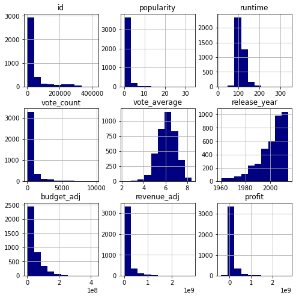

```python
#using .hist to create histograms for all numerical variables to see if they data is distributed noramally
df.hist(color='Navy',figsize= (8,8));
```

> The results show that the data contained within all numerical variables is skewed with the only variable that comes close to a normal distribution is vote_average although the variable is still slightly skewed to the left.

### Research Question 2. What were the Movies that contain the highest and lowest revenue and what year were the released?

```python
#checking movie with max and min revenue
df["revenue_adj"].max(), df["revenue_adj"].min()
```

```
(2827123750.41189, 2.37070528956505)
```

```python
df_max_rev = df[['original_title', 'revenue_adj']][df['revenue_adj'] == 2827123750.41189]
df_max_rev.head()
```

|  | original_title | revenue_adj |
| --- | --- | --- |
| 1386 | Avatar | 2827123750.41 |

```python
df_min_rev = df[['original_title', 'revenue_adj']][df['revenue_adj'] == 2.37070528956505]
df_min_rev.head()
```

|  | original_title | revenue_adj |
| --- | --- | --- |
| 5067 | Shattered Glass | 2.37 |

> Using the max and min functions I was able to find the movie that contained the highest and lowest revenue values within the datset. The results shows us that Avatar released in 2009 is the Movie that generated the highest revenue with a stargerring amount of 2.8bn US Dollars.

> The results also shows us that Shattered Glass released in 2003 is the Movie that generated the lowest revenue with a measly amount of 2 US Dollars.

### Research Question 3. What are the Movies that contain the highest and the lowest budgets and what production companies made the film?

```python
#checking movie with max and min budget
df["budget_adj"].max(), df["budget_adj"].min()
```

```
(425000000.0, 0.9693980425914721)
```

```python
#pulling the movies with max budget
df_max_budg = df[["original_title", "budget_adj"]][df['budget_adj'] == 425000000.0]

df_max_budg.head()
```

|  | original_title | budget_adj |
| --- | --- | --- |
| 2244 | The Warrior's Way | 425000000.00 |

```python
#pulling the movies with min budget
df_min_budg = df[["original_title", "budget_adj"]][df['budget_adj'] == 0.9693980425914721]

#df_min_budg = [df['original_title', 'budget_adj', 'production_companies'][df['budget_adj']] == 0.9693980425914721]

df_min_budg.head()
```

|  | original_title | budget_adj |
| --- | --- | --- |
| 3581 | Love, Wedding, Marriage | 0.97 |

> Using the max and min functions I was able to find the movies that contained the highest and lowest budgets within the datset. The results shows us that "The Warrior's Way" produced by Boram Entertainment Inc. was released in 2010 and is the movie that contained the highest budget consisting of 425m US Dollars.

> The results also shows us that the movie "Love, Wedding, Marriage" produced by 120dB Films, Scion Films and Voodoo Production Services and released in 2011 is the movie that contained the lowest budget consisting of 1 US Dollar.

### Research Question 4. What are the top five Movies with the highest profit?

```python
top5_rev = df[['original_title', 'profit']].nlargest(5,'profit')
top5_rev.head(5)
```

|  | original_title | profit |
| --- | --- | --- |
| 1329 | Star Wars | 2750136650.92 |
| 1386 | Avatar | 2586236847.52 |
| 5231 | Titanic | 2234713671.21 |
| 10594 | The Exorcist | 2128035624.57 |
| 9806 | Jaws | 1878643093.71 |

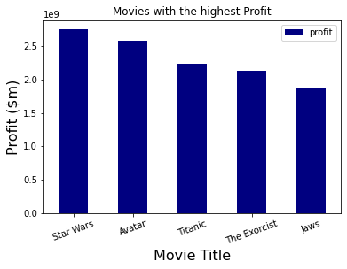

```python
top5_rev.plot(x='original_title', y='profit', kind='bar', color='Navy')
plt.xticks(rotation=20, horizontalalignment="center")
plt.title("Movies with the highest Profit")
plt.xlabel('Movie Title', fontsize=16)
plt.ylabel('Profit ($m)', fontsize=16)
#plt.show
```

> To find the top five movies with the highest profit I used the "nlargest" function and from there I proceeded to create a bar chart using the matplot library to visualize my findings.

> Interestingly our findings show us that although Avator generated the most revenue as seen earlier it was in fact Star Wars that made the most profit with nearly 2.8 billion US dollars according to the data provided.

### Research Question 5. Plot Vote Average vs Profit to see if the most profitable Movies contain the highest average votes?

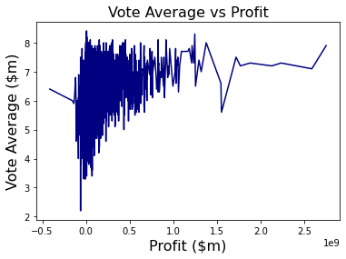

```python
#using the groupby function to group the data and then plot according movie profit and the vote the vote the movie received.
df.groupby('profit')['vote_average'].mean().plot(color='Navy')
plt.title("Vote Average vs Profit", fontsize=16)
plt.xlabel('Profit ($m)', fontsize=16)
plt.ylabel('Vote Average ($m)', fontsize=16)
```

> Lets pull out the top 10 Movies that contain the highest votes from the audience to see what charecteristics they posess.

```python
#pulling out Movies with the top 10 average votes
top10_rat = df[['original_title', 'genres', 'director', 'production_companies','vote_average', 'release_year', 'budget_adj', 'revenue_adj', 'profit']].nlargest(10,'vote_average')
top10_rat.head(10)
```

|  | original_title | genres | director | production_companies | vote_average | release_year | budget_adj | revenue_adj | profit |
| --- | --- | --- | --- | --- | --- | --- | --- | --- | --- |
| 4178 | The Shawshank Redemption | Drama\|Crime | Frank Darabont | Castle Rock Entertainment | 8.40 | 1994 | 36777789.04 | 41693462.72 | 4915673.68 |
| 7948 | Stop Making Sense | Documentary\|Music | Jonathan Demme | Talking Heads\|Arnold Stiefel Company | 8.40 | 1984 | 2518850.45 | 10450966.59 | 7932116.14 |
| 7269 | The Godfather | Drama\|Crime | Francis Ford Coppola | Paramount Pictures\|Alfran Productions | 8.30 | 1972 | 31287365.59 | 1277913732.39 | 1246626366.80 |
| 650 | Whiplash | Drama\|Music | Damien Chazelle | Bold Films\|Blumhouse Productions\|Right of Way ... | 8.20 | 2014 | 3039600.47 | 12888912.73 | 9849312.27 |
| 2409 | Fight Club | Drama | David Fincher | Regency Enterprises\|Fox 2000 Pictures\|Taurus F... | 8.10 | 1999 | 82470329.34 | 132022892.45 | 49552563.12 |
| 2875 | The Dark Knight | Drama\|Action\|Crime\|Thriller | Christopher Nolan | DC Comics\|Legendary Pictures\|Warner Bros.\|Syncopy | 8.10 | 2008 | 187365527.25 | 1014733032.48 | 827367505.23 |
| 4177 | Pulp Fiction | Thriller\|Crime | Quentin Tarantino | Miramax Films\|A Band Apart\|Jersey Films | 8.10 | 1994 | 11768892.49 | 314713075.14 | 302944182.64 |
| 4179 | Forrest Gump | Comedy\|Drama\|Romance | Robert Zemeckis | Paramount Pictures | 8.10 | 1994 | 80911135.89 | 997333314.60 | 916422178.71 |
| 9758 | The Godfather: Part II | Drama\|Crime | Francis Ford Coppola | Paramount Pictures\|The Coppola Company | 8.10 | 1974 | 57489690.55 | 210247939.77 | 152758249.22 |
| 10222 | Schindler's List | Drama\|History\|War | Steven Spielberg | Universal Pictures\|Amblin Entertainment | 8.10 | 1993 | 33208339.16 | 484941026.52 | 451732687.36 |

> The list shows that "The Shawshank Redemption" received the highest votes from the audience but only managed to make just under 5m US Dollars in profit. Further down the list we can see that "The Dark Night" had a large budget to make the movie, generated over 1bn US Dollars and made 827m uS Dollars in profit from the movie, while also scoring very high @ 8.1. A success all round for everyone involved would'nt you say.

> Drama & Crime genres feature quite frequently within our top voters list and later on we will find out if that trend occurs throughout the datset.

> The above way of analysing relationships provided us with good information but now lets use correaltion methods to answer the next questions which are similar in nature.

### Research Question 6. Is there a strong correlation between Revenue and Profit, and Budget and Profit?

[figure not shown]

```python
#using a scatter plot to see how string the relationship is between Profit and Revenue
df.plot(x='revenue_adj', y='profit', kind='scatter', color='Navy');
plt.title("Profit vs Revenue", fontsize=16)
plt.xlabel('Profit ($m)', fontsize=16)
plt.ylabel('Revenue ($m)', fontsize=16)
```

> The results from the Profit vs Revenue scatter plot show there is a strong relationship between the two variables meaning that money generated from the movie is closely aligned to the amount of profit the movie made i.e. when revenue increases profit increases.

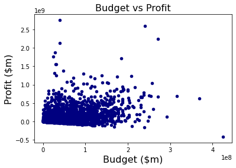

```python
#using a scatter plot to see how string the relationship is between Budget and Profit
df.plot(x='budget_adj', y='profit', kind='scatter', color='Navy');
plt.title("Budget vs Profit", fontsize=16)
plt.xlabel('Budget ($m)', fontsize=16)
plt.ylabel('Profit ($m)', fontsize=16)
```

> Let us now confirm my interpretation on the relationships between the selected variavles by conducting a Correlation Coefficient (Pearsons's r) statistical test.

```python
#using the Pearson Method within .corr to determine the standard correlation coefficient between the selected variables

#Pearsons: Standard Correlation Coefficient
p_corr = df[['budget_adj', 'revenue_adj', 'profit',]].corr(method='pearson')
p_corr
```

|  | budget_adj | revenue_adj | profit |
| --- | --- | --- | --- |
| budget_adj | 1.00 | 0.57 | 0.40 |
| revenue_adj | 0.57 | 1.00 | 0.98 |
| profit | 0.40 | 0.98 | 1.00 |

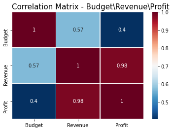

```python
#using a heat map to visualize the results. Reference: "https://levelup.gitconnected.com/pearson-coefficient-of-correlation-using-pandas-ca68ce678c04"

x_axis_labels = ['Budget', 'Revenue', 'Profit' ] # labels for x-axis
y_axis_labels = ['Budget', 'Revenue', 'Profit' ] # labels for y-axis

sb.heatmap(p_corr,
            #xticklabels=p_corr.columns,
            #yticklabels=p_corr.columns,
            xticklabels=x_axis_labels,
            yticklabels=y_axis_labels,
            cmap='RdBu_r',
            annot=True,
            linewidth=0.5)
title = 'Correlation Matrix - Budget\Revenue\Profit'
plt.title(title, loc='left', fontsize=15)

plt.show()
```

> The results of the Pearson's Correlation Coefficient statistical method that was conducted are displayed in tabular form and also within the above heatmap enable me to confirm there is a very strong positive correaltion between Revenue and Profit conissiting of a 0.98 coefficient that means when Revenue increases Profit also increases. The heatmap also confirms a low moderate coefficient of 0.4 between Budget and Profit meaning a high budget does not necessarily translate to high Profit.

> Lets take this one step further and see if there is a high correlation between many of the other key variables witin the dataset.

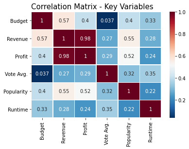

```python
#using a heat map to visualize the results. Reference: "https://levelup.gitconnected.com/pearson-coefficient-of-correlation-using-pandas-ca68ce678c04"
#Pearsons: Standard Correlation Coefficient
p_corr2 = df[['budget_adj', 'revenue_adj', 'profit', 'vote_average', 'popularity', 'runtime']].corr(method='pearson')
#p_corr



x_axis_labels = ['Budget', 'Revenue', 'Profit', 'Vote Avg.', 'Popularity', 'Runtime'] # labels for x-axis
y_axis_labels = ['Budget', 'Revenue', 'Profit', 'Vote Avg.', 'Popularity', 'Runtime'] # labels for y-axis

sb.heatmap(p_corr2,
            #xticklabels=p_corr.columns,
            #yticklabels=p_corr.columns,
            xticklabels=x_axis_labels,
            yticklabels=y_axis_labels,
            cmap='RdBu_r',
            annot=True,
            linewidth=0.5)
title = 'Correlation Matrix - Key Variables'
plt.title(title, loc='left', fontsize=15, )

plt.show()
```

> The above correrlation matrix highlights that there are no strong relationships excluding the revenue and profit relationship we highlighted earlier, although popularity does contain a positive moderate relationship with both revenue and profit which makes sense as the more popular a movie is it is likely to generate more revene and profit. The matrix also show what we discovered earlier in the there is a weak relationship between voting average and profit as well as voting average and revenue.

> Finally, Budget and Revenue dispays a positive moderate relationship consisting of a 0.57 coefficient meaning when budgets increase revenue tends to as well but high budgets as we know doesnt translate to high profits.

### Research Question 7: What Genres feature most frequently within the data.

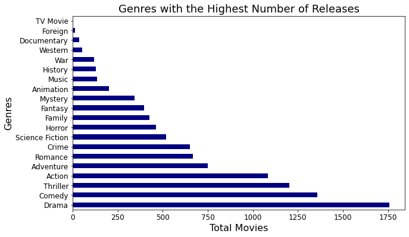

```python
#function that will split the string and return the count of each genre.
#This is required as movies can contain multiple genres & are divided by a | within the data
#reference: https://www.kaggle.com/deepak525/investigate-tmdb-movie-dataset
def cnt_genre(x):
    #concatenate all the rows of the genres.
    data_plot = df[x].str.cat(sep = '|')
    data = pd.Series(data_plot.split('|'))
    #counts each one of the genres within row and returns the number.
    info = data.value_counts(ascending=False)
    return info

#calling the function for counting the movies of each genre.
total_genres = cnt_genre('genres')
#plotting a horizontal barchart using the plot function.
total_genres.plot(kind= 'barh',figsize = (10,6),fontsize=12,color='Navy')

#setup the title and the labels of the plot.
plt.title("Genres with the Highest Number of Releases",fontsize=18)
plt.xlabel('Total Movies',fontsize=16)
plt.ylabel("Genres",fontsize= 16)
sb.set_style("darkgrid")
```

> The results show that the small sample size we oberved within Question 5 proved a good indicator as the Drama genre features most with 1,750 releases over the time period, the Crime genre also features quite regularly with over 600 appearances. Although, there were some suprises for me with the War & History Genres appearing less than 200 times each as I do love a good historic war film.

### Research Question 8. Do the number of Movies released increase by year and how do budget, reveunue and profit trend over time.

```python
#finding out how many movies were made by year
mpy = pd.DataFrame(df.groupby('release_year').original_title.nunique())
mpy.head(5)
mpy.tail()
```

| release_year | original_title |
| --- | --- |
| 2011 | 199 |
| 2012 | 158 |
| 2013 | 180 |
| 2014 | 165 |
| 2015 | 160 |

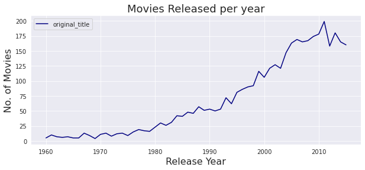

```python
# Plotting a line chart for the number of movies released over time
mpy.plot.line(title = 'Movies per year',color='navy', figsize=(10, 4));

#title and the labels for the line chart.
plt.title("Movies Released per year",fontsize=18)
plt.xlabel('Release Year',fontsize=16)
plt.ylabel("No. of Movies",fontsize= 16)
```

> The Graph shows that the number of Movies released increase overtime with less than twenty released in 1960 in comparison to two-hundred released in 2011. The line chart also illustrates there was a drop off in movie releases post 2011.

> Now lets look at Budget, Revenue and Profit over time.

```python
#using groupby to split the data by release_year and calculating the mean values for each desired variable
mpy_mean = df.groupby('release_year')[['budget_adj', 'revenue_adj', 'profit']].mean()
mpy_mean.head()
```

| release_year | budget_adj | revenue_adj | profit |
| --- | --- | --- | --- |
| 1960 | 30681790.10 | 190229933.36 | 159548143.27 |
| 1961 | 28185155.25 | 246362189.86 | 218177034.61 |
| 1962 | 40624758.32 | 212474021.01 | 171849262.68 |
| 1963 | 72524960.38 | 209483843.96 | 136958883.57 |
| 1964 | 34081893.78 | 330034445.30 | 295952551.52 |

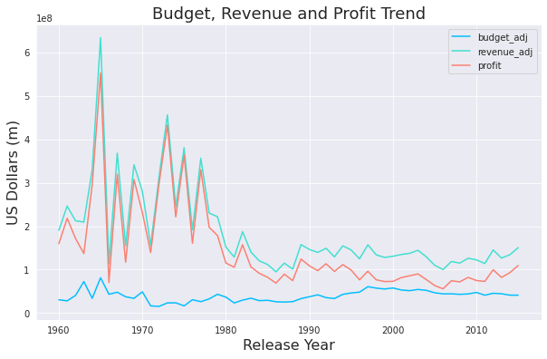

```python
mpy_mean.plot(color=('deepskyblue','turquoise','salmon'), figsize=(10, 6));
#setup the title and the labels of the plot.
plt.title("Budget, Revenue and Profit Trend",fontsize=18)
plt.xlabel('Release Year',fontsize=16)
plt.ylabel("US Dollars (m)",fontsize= 16)
```

> The adjusted revenue and profit averages remain closely aligned as expected and they show huge volatility in the first twenty years and then level out from 1990 onwards. The volatility in the early years is most likely due to the low number of movies released in the 60s and 70s as previously noted - let us now use the release_decade variable that was created earlier using numpy's select condition list to see exactly how many movies were made per decade.

```python
#finding out exactly how many movies were made by decade
mpd = pd.DataFrame(df.groupby('release_decade').original_title.nunique())
mpd.head(6)
```

| release_decade | original_title |
| --- | --- |
| a) 60s | 71 |
| b) 70s | 133 |
| c) 80s | 395 |
| d) 90s | 755 |
| e) Noughties | 1459 |
| f) 2010-2015 | 1040 |

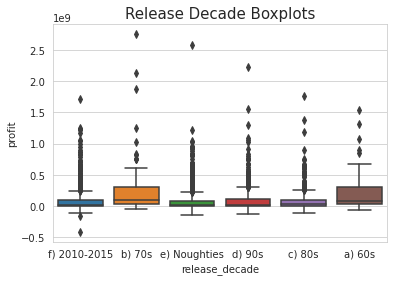

```python
#creating a boxplot graph to investigate each decade by profit now that we know exact no. of releases per decade
#The Boxplots willdisplay the data through their quartiles where we can detect outliers within each decade.
sb.set_style("whitegrid")

sb.boxplot(x = 'release_decade', y = 'profit', data = df)

title = 'Release Decade Boxplots'
plt.title(title, loc='center', fontsize=15)
```

```python
#creating df to look at sixties and seventies outliers by profit as the boxplots show each decade contains outliers
#the boxplot also clearly displays that the movie with the highest profit was released in the 70s
six_sev = df[['original_title', 'release_year', 'release_decade','profit']].query('release_decade == "a) 60s" or release_decade == "b) 70s"')
six_sev.head()
```

|  | original_title | release_year | release_decade | profit |
| --- | --- | --- | --- | --- |
| 1329 | Star Wars | 1977 | b) 70s | 2750136650.92 |
| 1330 | The Spy Who Loved Me | 1977 | b) 70s | 616798805.97 |
| 1331 | The Rescuers | 1977 | b) 70s | 251901765.47 |
| 1332 | Annie Hall | 1977 | b) 70s | 123229127.20 |
| 1334 | Close Encounters of the Third Kind | 1977 | b) 70s | 1021009368.26 |

```python
#pulling out the outliers within the sixtes and seventies df
six_sev_top = six_sev[['original_title', 'release_year', 'profit']].nlargest(10,'profit')
six_sev_top.head(10)
```

|  | original_title | release_year | profit |
| --- | --- | --- | --- |
| 1329 | Star Wars | 1977 | 2750136650.92 |
| 10594 | The Exorcist | 1973 | 2128035624.57 |
| 9806 | Jaws | 1975 | 1878643093.71 |
| 10110 | One Hundred and One Dalmatians | 1961 | 1545635294.87 |
| 10398 | The Jungle Book | 1967 | 1319404004.03 |
| 7269 | The Godfather | 1972 | 1246626366.80 |
| 10690 | The Sound of Music | 1965 | 1072786239.70 |
| 1334 | Close Encounters of the Third Kind | 1977 | 1021009368.26 |
| 10689 | Thunderball | 1965 | 901027343.84 |
| 9881 | Goldfinger | 1964 | 853474463.61 |

> Upon further investigation into why the Budget, Revenue and Profit Trend displayed volatility and spikes in Revenue and Budget for the sixties and seventies I found that the number of Movies released throughout both decades were insignificant in comparison to the number of Movies released in later decades - 71 in the Sixties vs 1,459 throughout the Nougties, this could be one reason why the average profit for movies made throughout those decades were so high as there were a lot less movies to chose from in comparison to later decades.

> I also found that the movie containing the highest profit was released in 1977, while various other high earning movies were also released in the 60s and 70s. We do have to remember though that the variables we analysed here were the adjusted Revenue and Budget variables as the actualt figures would show much more discrepancy over time.

## Conclusions

### Limitations

> The Pearson correlation coefficient r, used to answer questions posed throughout this analysis, can take a range of values from +1 to -1. A value of 0 indicates that there is no association between the two variables. A value greater than zero indicates a positive relationship, If one variables increases so does the other. Additionall if a value is less than zero it indicates a negative relationship.

> It is important to note that when determining if a relationship is “very strong” or “very weak” is subjective and correlation does not mean causation. Two variables can be strongly correlated, but that does not mean that changes in one variable causes the other variable to change. Or maybe an additional variable is actually the cause of changes within the first two.

### References

> https://towardsdatascience.com/heatmap-basics-with-pythons-seaborn-fb92ea280a6c

> https://levelup.gitconnected.com/pearson-coefficient-of-correlation-using-pandas-ca68ce678c04

> https://www.kaggle.com/deepak525/investigate-tmdb-movie-dataset

> https://www.quora.com/What-are-the-limitations-of-correlation-coefficient

> https://www.kaggle.com/lorenzhering/movie-data-analysis